# Complication Risk Model: SDSC Analytic Pitch

Walker Blackston, MSPH

2025-04-04

# Background

To demonstrate how I think through surgical outcome prediction and statistical problems, I built a prototype risk model for 30-day complications based on simulated surgical data.

In this hypothetical dataset of 1,000 patients, we sought to compare predictors of complications at 30-days follow up from surgery. We simulated a variety of demographic and clinical variables based on seeds of real-world data and expected distributions in a random sample of patients. The following brief will highlight steps in the analysis, modeling and interpretation of findings. A full printout of code used to generate data and this document are available in the Github provided in my pitch.

## Data Summary

**Table: Summary Statistics by 30-Day Complication Status**

| **Variable** | **No Complication** N = 927<sup>1</sup> | **Complication** N = 73<sup>1</sup> | **p-value**<sup>2</sup> |
| --- | --- | --- | --- |
| Age | 59.22 (14.06) | 65.99 (12.11) | <0.001 |
| BMI | 27.00 (4.69) | 27.49 (5.11) | 0.6 |
| Surgery_Duration_Minutes | 95.95 (39.79) | 113.55 (47.64) | 0.001 |
| Estimated_Blood_Loss | 126.47 (98.13) | 143.85 (107.14) | 0.2 |

<sup>1</sup> Mean (SD)  
<sup>2</sup> Wilcoxon rank sum test

**Table: Procedure Type Distribution by 30-Day Complication Status**

| **Procedure Type** | **No Complication** N = 927<sup>1</sup> | **Complication** N = 73<sup>1</sup> | **p-value**<sup>2</sup> |
| --- | --- | --- | --- |
| Procedure_Type |  |  | 0.2 |
| Appendectomy | 128 (14%) | 13 (18%) |  |
| Colectomy | 242 (26%) | 13 (18%) |  |
| Gastrectomy | 80 (8.6%) | 10 (14%) |  |
| Hernia Repair | 183 (20%) | 18 (25%) |  |
| Lap Chole | 294 (32%) | 19 (26%) |  |
| Intraoperative_Events | 138 (15%) | 21 (29%) | 0.002 |
| ASA_Class |  |  | 0.039 |
| 1 | 83 (9.0%) | 8 (11%) |  |
| 2 | 290 (31%) | 18 (25%) |  |
| 3 | 352 (38%) | 22 (30%) |  |
| 4 | 159 (17%) | 16 (22%) |  |
| 5 | 43 (4.6%) | 9 (12%) |  |

<sup>1</sup> n (%)  
<sup>2</sup> Pearson’s Chi-squared test; Fisher’s exact test

# Exploring the data

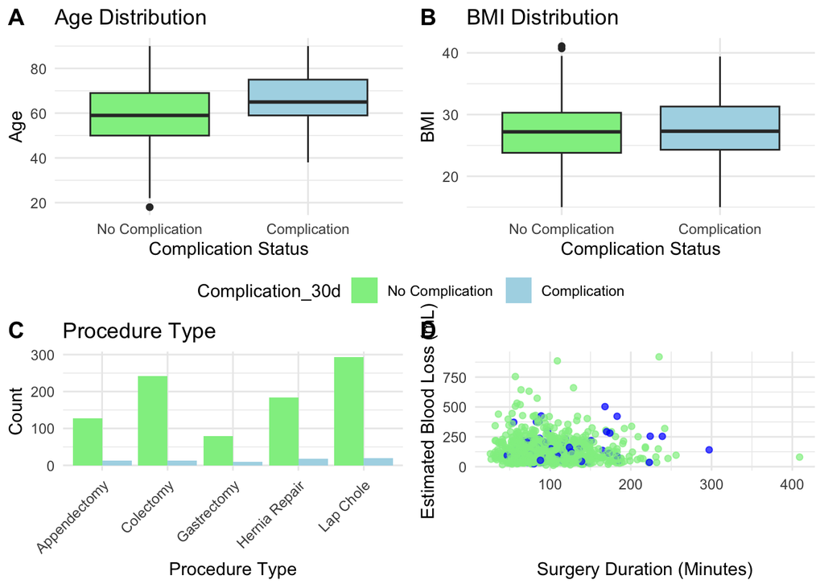

# Predictive Modeling

## Logistic Model

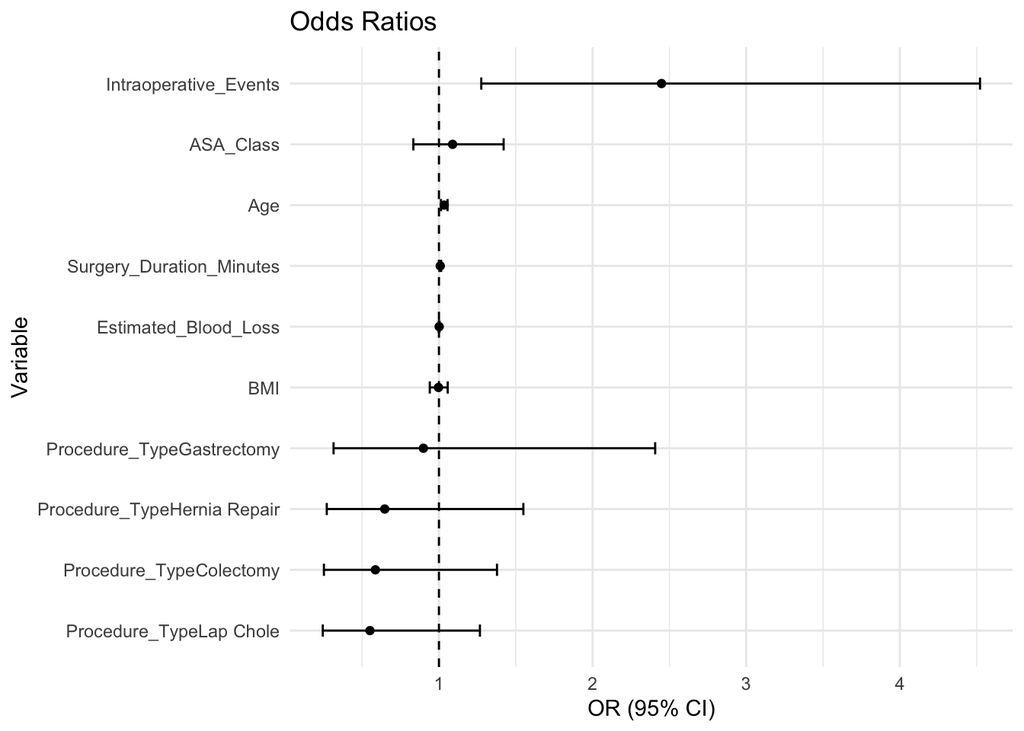

## Machine Learning Model (Random Forest)

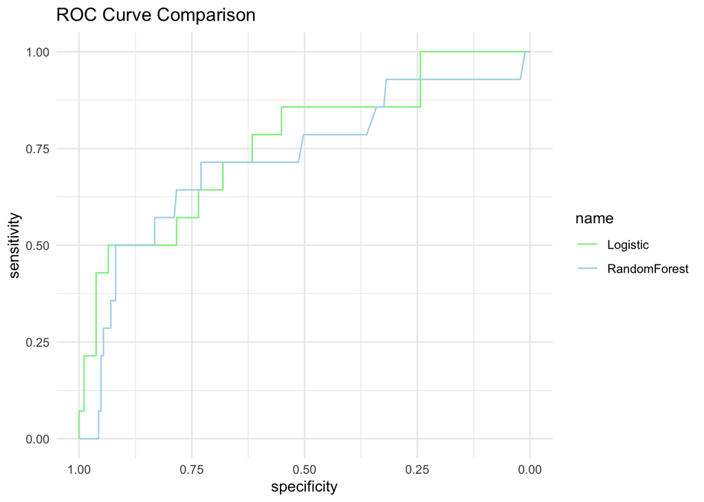

## Results

The model achieved an AUC (Logistic): 0.76 and AUC(RandomForest): 0.72, respectively with higher odds of complication associated only with:

- Advanced age
- Intra-operative events

## Accuracy and Interpretation

Confusion Matrix (Logistic Regression)

| Prediction Reference | No Complication | Complication |
| --- | --- | --- |
| No Complication | 185 | 13 |
| Complication | 0 | 1 |

Overall Performance Metrics (Logistic Regression)

| Accuracy | Kappa | AccuracyLower | AccuracyUpper | AccuracyNull | AccuracyPValue | McnemarPValue |
| --- | --- | --- | --- | --- | --- | --- |
| 0.93 | 0.13 | 0.89 | 0.96 | 0.93 | 0.46 | 0 |

Class-Specific Performance Metrics (Logistic Regression)

| Sensitivity | Specificity | Pos Pred Value | Neg Pred Value | Precision | Recall | F1 | Prevalence | Detection Rate | Detection Prevalence | Balanced Accuracy |
| --- | --- | --- | --- | --- | --- | --- | --- | --- | --- | --- |
| 1 | 0.07 | 0.93 | 1 | 0.93 | 1 | 0.97 | 0.93 | 0.93 | 0.99 | 0.54 |

Confusion Matrix (Random Forest)

| Prediction Reference | No Complication | Complication |
| --- | --- | --- |
| No Complication | 185 | 14 |
| Complication | 0 | 0 |

Overall Performance Metrics (Random Forest)

| Accuracy | Kappa | AccuracyLower | AccuracyUpper | AccuracyNull | AccuracyPValue | McnemarPValue |
| --- | --- | --- | --- | --- | --- | --- |
| 0.93 | 0 | 0.88 | 0.96 | 0.93 | 0.57 | 0 |

Class-Specific Performance Metrics (Random Forest)

| Sensitivity | Specificity | Pos Pred Value | Neg Pred Value | Precision | Recall | F1 | Prevalence | Detection Rate | Detection Prevalence | Balanced Accuracy |
| --- | --- | --- | --- | --- | --- | --- | --- | --- | --- | --- |
| 1 | 0 | 0.93 | NaN | 0.93 | 1 | 0.96 | 0.93 | 0.93 | 1 | 0.5 |

## Next Steps

This model demonstrates early potential to extract explainable risk signals from surgical outcomes data. If advanced with real-world video and procedural metadata, the insights could power a live surgeon feedback loop or benchmark dashboard.